# cQuant programming exercise

Alexander Mitroff

Task 1: Read in all the historical data and combine it into a single data structure (data frame, table, etc.).

```r
defaultW <- getOption("warn")
options(warn = -1)
setwd("~/Jobs/cQuant")
library(readr)
library(tidyverse)
library(data.table)
library(lubridate)
ERCOT_DA_Prices_2016 <- read_csv("historicalPriceData/ERCOT_DA_Prices_2016.csv")
ERCOT_DA_Prices_2017 <- read_csv("historicalPriceData/ERCOT_DA_Prices_2017.csv")
ERCOT_DA_Prices_2018 <- read_csv("historicalPriceData/ERCOT_DA_Prices_2018.csv")
ERCOT_DA_Prices_2019 <- read_csv("historicalPriceData/ERCOT_DA_Prices_2019.csv")
data<-rbind(ERCOT_DA_Prices_2016,ERCOT_DA_Prices_2017,ERCOT_DA_Prices_2018,ERCOT_DA_Prices_2019)
```

## Locational Nature of Power Prices

**Task 2:** Compute the average price for each settlement point and year-month in the historical dataset (48 year-months: January 2016 through December 2019).

```r
data$Year<-lubridate::year(data$Date)
data$Month<-lubridate::month(data$Date)
meansum<-data %>%
  group_by(Year, Month, SettlementPoint) %>%
  summarise_at(vars(Price), list(Price = mean))
```

**Task 3:** Write the computed monthly average prices to file as a CSV named AveragePriceByMonth.csv.

```r
write.csv(meansum, "AveragePriceByMonth.csv", row.names=FALSE)
```

## Price Volatility

**Task 4:** Compute the hourly price1 volatility for each year and each settlement hub in the historical power price data (hubs are denoted by the prefix “HB_” in the SettlementPoint name).

```r
data2<-data
data2[data2 <= 0] <- NA
data2 <- na.omit(data2)
#summary(data2$Price)
data2$logprice<-log(data2$Price)
volatility<-data2 %>%
  group_by(Year, SettlementPoint) %>%
  summarise_at(vars(logprice), list(HourlyVolatility = sd))
volatility<-volatility[!grepl('LZ_', volatility$SettlementPoint),]
```

**Task 5:** Write the computed hourly volatilities for each settlement hub and each historical year to file as a CSV named HourlyVolatilityByYear.csv.

```r
write.csv(volatility, "HourlyVolatilityByYear.csv", row.names=FALSE)
```

**Task 6:** Determine which settlement hub showed the highest overall hourly volatility for each historical year. Write code to extract the rows of your computed hourly volatility table corresponding to these maxima and write this table to a second output file named MaxVolatilityByYear.csv.

```r
yearlist<-unique(volatility$Year)
yearmax<-c()
spmax<-c()
for (i in yearlist){
  yearmax<-append(yearmax,max((filter(volatility, Year == i)$HourlyVolatility)))
  sp<-which(volatility$HourlyVolatility==max((filter(volatility, Year == i)$HourlyVolatility)))
  spmax<-append(spmax,volatility$SettlementPoint[sp])
}
Maxes<-data.frame(Year = yearlist,
                  SettlementPoint = spmax,
                  HourlyVolatility = yearmax)
write.csv(Maxes, "MaxVolatilityByYear.csv", row.names=FALSE)
```

## Data Translation and Formatting

**Task 7:** Use the files in the supplementalMaterials folder as examples of the required data format, write code to translate the power price data structure you created in Task 1 into a format that could be readily consumed by the cQuant price simulation models, and write the data to separate files for each settlement point.

```r
library(padr)
colnames<-list('Variable','Date','X1','X2','X3','X4','X5','X6','X7','X8','X9','X10','X11','X12','X13','X14','X15','X16','X17','X18','X19','X20','X21','X22','X23','X24')
data$Day<-lubridate::day(data$Date)
data$Hour<-lubridate::hour(data$Date)
data$cleandate<-format(as.POSIXct(data$Date,format='%m/%d/%Y %H:%M:%S'),format='%m/%d/%Y')
sp_list<-unique(data$SettlementPoint)
day_list<-unique(data$cleandate)
for (i in sp_list){
  df_i=data.frame(matrix(ncol = length(colnames), nrow = 0))
  names(df_i)<-colnames
  currentsp<-filter(data,data$SettlementPoint==i)
  for (j in day_list){
    currentday<-filter(currentsp,cleandate==j)
    if (nrow(currentday)<24) {
    currentday<-pad(currentday)
    }
    rowdata<-t(currentday$Price)
    newrow<-c(i,j,rowdata)
    df_i[nrow(df_i) + 1,] = newrow
  }
  write.csv(df_i, paste0("spot_",i,".csv"), row.names=FALSE)
}
```

## Bonus - Mean Plots

Generate two line plots that display the monthly average prices you computed in Task 2 in chronological order, according to the following specification: [See PDF]

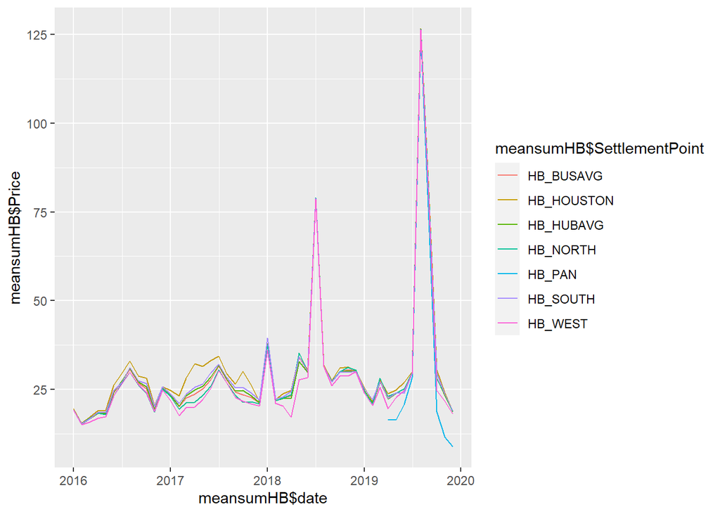

```r
meansum2<-meansum %>% mutate(date = make_date(Year, Month))
meansumHB<-meansum2[!grepl('LZ_', meansum2$SettlementPoint),]
meansumLZ<-meansum2[!grepl('HB_', meansum2$SettlementPoint),]
ggplot(data = meansumHB, aes(x=meansumHB$date, y=meansumHB$Price)) + geom_line(aes(color=meansumHB$SettlementPoint))
```

```r
ggsave("SettlementHubAveragePriceByMonth.png",width = 12,height = 7)
```

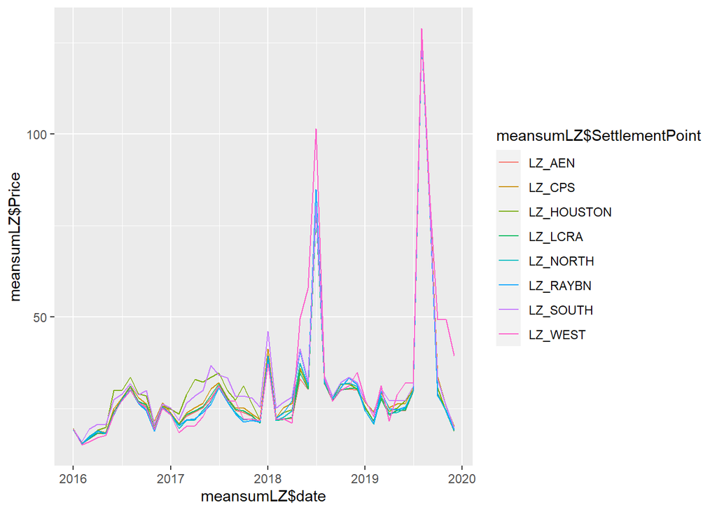

```r
ggplot(data = meansumLZ, aes(x=meansumLZ$date, y=meansumLZ$Price)) + geom_line(aes(color=meansumLZ$SettlementPoint))
```

```r
ggsave("LoadZoneAveragePriceByMonth.png",width = 12,height = 7)
```